# Self-Driving Car Engineer Nanodegree

## Project: Build a Traffic Sign Recognition Classifier

For more information please check README.md

## Step 0: Load The Data

```python
# Load pickled data
import pickle

# TODO: Fill this in based on where you saved the training and testing data

training_file = "traffic-signs-data/train.p"
validation_file= "traffic-signs-data/valid.p"
testing_file = "traffic-signs-data/test.p"

with open(training_file, mode='rb') as f:
    train = pickle.load(f)
with open(validation_file, mode='rb') as f:
    valid = pickle.load(f)
with open(testing_file, mode='rb') as f:
    test = pickle.load(f)

X_train, y_train, s_train, c_train = train['features'], train['labels'], train['sizes'], train['coords']
X_valid, y_valid, s_valid, c_valid = valid['features'], valid['labels'], valid['sizes'], valid['coords']
X_test, y_test, s_test, c_test = test['features'], test['labels'], test['sizes'], test['coords']
```

## Step 1: Dataset Summary & Exploration

The pickled data is a dictionary with 4 key/value pairs:

- `'features'` is a 4D array containing raw pixel data of the traffic sign images, (num examples, width, height, channels).
- `'labels'` is a 1D array containing the label/class id of the traffic sign. The file `signnames.csv` contains id -> name mappings for each id.
- `'sizes'` is a list containing tuples, (width, height) representing the original width and height the image.
- `'coords'` is a list containing tuples, (x1, y1, x2, y2) representing coordinates of a bounding box around the sign in the image. **THESE COORDINATES ASSUME THE ORIGINAL IMAGE. THE PICKLED DATA CONTAINS RESIZED VERSIONS (32 by 32) OF THESE IMAGES**

### Basic Summary of the Data Set Using Python, Numpy and/or Pandas

```python
import pandas

# TODO: Number of training examples
n_train = X_train.shape[0]

# TODO: Number of validation examples
n_validation = X_valid.shape[0]

# TODO: Number of testing examples.
n_test = X_test.shape[0]

# TODO: What's the shape of an traffic sign image?
image_shape = X_train[0].shape

#read signnames.csv
signnames = pandas.read_csv("signnames.csv")

# TODO: How many unique classes/labels there are in the dataset.
n_classes = signnames.shape[0]

print("Number of training examples =", n_train)
print("Number of validating examples =", n_validation)
print("Number of testing examples =", n_test)
print("Image data shape =", image_shape)
print("Number of classes =", n_classes)
```

```
Number of training examples = 34799
Number of validating examples = 4410
Number of testing examples = 12630
Image data shape = (32, 32, 3)
Number of classes = 43
```

### Exploratory visualization of the dataset

Here the German Traffic Signs Dataset from pickled files will be visualized.

Histogram for samples in the datasets:

[figure not shown]

```python
### Data exploration visualization code goes here.
import matplotlib.pyplot as plt
import numpy as np
from collections import Counter

# Visualizations will be shown in the notebook.
%matplotlib inline

# the histogram of the data
y = (n_train,n_validation,n_test)
x = ('train', 'validate','test')
x_pos = np.arange(len(x))

fig, axes = plt.subplots(nrows=2, ncols=2,figsize=(10, 10))

ax = axes[0,0]
# Example data
bars = ax.bar(x_pos, y, align='center',
        color='green')
ax.set_xticks(x_pos)
ax.set_xticklabels(x)
ax.set_xlabel('samples')
ax.set_ylabel('number of samples')
ax.set_title('Samples in diff. groups')

i = 0#this variable will be need later to select proper label for a histogram

for bar in bars:
    # Rectangle widths are already integer-valued but are floating
    # type, so it helps to remove the trailing decimal point and 0 by
    # converting width to int type

    height = int(bar.get_height())

    yloc = height - 1200
    align = 'center'
    clr = 'white'#label color

    # Center the text vertically in the bar
    xloc = bar.get_x() + bar.get_width()/2.0
    label = ax.text(xloc, yloc, y[i], horizontalalignment=align,
                     verticalalignment='center', color=clr, weight='bold',
                     clip_on=True)
    i+=1

signs = signnames['ClassId'].values

#histogram for training data
ax1 = axes[0,1]
x_pos = np.arange(len(signs))
freq = Counter(y_train)#counts labels in train data
freq = sorted(freq.items(), key=lambda pair: (pair[0], pair[1]))
freq = [y for (i,y) in freq]

ax1.bar(x_pos, freq, align='center',
        color='green', ecolor='black')
ax1.set_ylabel("frequency")
ax1.set_xlabel('ClassId')
ax1.set_title('ClassId distribution in training set')

#histogram for validation data
ax1 = axes[1,0]
x_pos = np.arange(len(signs))
freq = Counter(y_valid)#counts labels in train data
freq = sorted(freq.items(), key=lambda pair: (pair[0], pair[1]))

freq = [y for (i,y) in freq]

ax1.bar(x_pos, freq, align='center',
        color='green', ecolor='black')
ax1.set_ylabel("frequency")
ax1.set_xlabel('ClassId')
ax1.set_title('ClassId distribution in validation set')

#histogram for test data
ax1 = axes[1, 1]
x_pos = np.arange(len(signs))
freq = Counter(y_test)#counts labels in train data
freq = sorted(freq.items(), key=lambda pair: (pair[0], pair[1]))
freq = [y for (i,y) in freq]

ax1.bar(x_pos, freq, align='center',
        color='green', ecolor='black')
ax1.set_ylabel("frequency")
ax1.set_xlabel('ClassId')
ax1.set_title('ClassId distribution in training set')


plt.show()
```

Visualization of random samples for every label. Here we check wheater data in the pickle object and in signnames.csv fit to each other.

```
ClassId                                           SignName
      0                               Speed limit (20km/h)
      1                               Speed limit (30km/h)
      2                               Speed limit (50km/h)
      3                               Speed limit (60km/h)
      4                               Speed limit (70km/h)
      5                               Speed limit (80km/h)
      6                        End of speed limit (80km/h)
      7                              Speed limit (100km/h)
      8                              Speed limit (120km/h)
      9                                         No passing
     10       No passing for vehicles over 3.5 metric tons
     11              Right-of-way at the next intersection
     12                                      Priority road
     13                                              Yield
```

[output cut: 29 more lines]

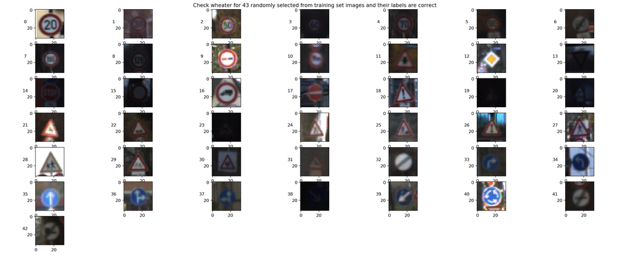

```python
import random
import math

fig = plt.figure(figsize=(25, 10), dpi=160)
ax = fig.add_subplot(111)    # The big subplot
ax.set_title('Check wheater for 43 randomly selected from training set images and their labels are correct')
ax.axis('off')


# generates a list of (n_train) random numbers in the
# range 0 to X_train without repetition
random_indexes = random.sample(range(n_train), n_train)

#calculate number of subplot to show all 43 signs
n_col = n_classes // int(math.sqrt(n_classes))
n_row = n_classes // n_col + n_classes % n_col


i = 0 #random image index

seen_labels = set()# cycle iterates over randomly selected images and compares them to the seen labels
                    #in seen_classes set(), if not in "seen yet" - found image will be show on subplot
images = []#each element in the array is a random signs, which label is a pisition in the array (len(images)=(42))
k=0#class number
while k<n_classes:
    if y_train[i] not in seen_labels:
        seen_labels.add(y_train[i])
        images.append((y_train[i],i))
        k+=1
        i+=1
    else:
        i+=1

images = sorted(images)
k = 1 #class/graph number
for label, index in images:
    image = X_train[index]
    ax = fig.add_subplot(n_row,n_col,k)
    ax.set_ylabel(y_train[index], rotation=0)
    plt.imshow(image)
    k+=1

print(signnames.to_string(index=False))
```

## Step 2: Design and Test a Model Architecture

### Pre-process the Data Set (normalization, grayscale, etc.)

For more details on chosen neural network architecture and image preprocessig please check README.md.

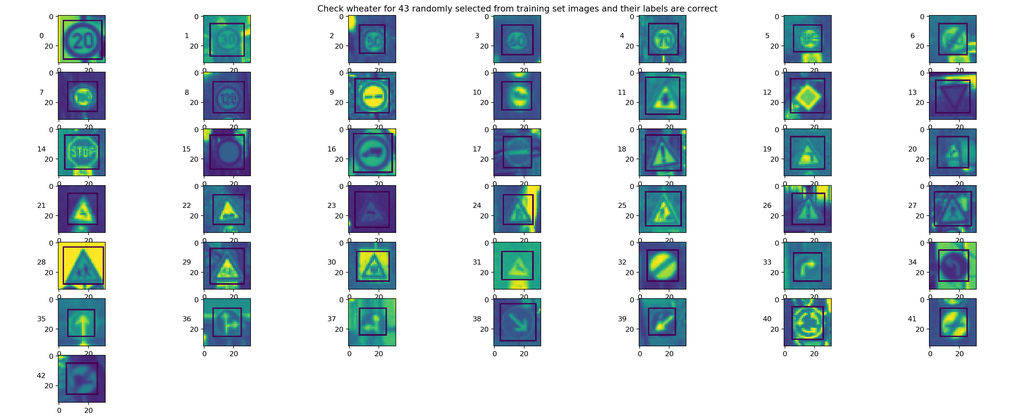

```python
### Preprocessing the data is here.
### Data will be converted to grayscale, trimmed and scaled.

import cv2

#convert to grayscale
def grayscale(img):
    """Applies the Grayscale transform
    This will return an image with only one color channel
    but NOTE: to see the returned image as grayscale
    (assuming your grayscaled image is called 'gray')
    you should call plt.imshow(gray, cmap='gray')"""
    return cv2.cvtColor(img, cv2.COLOR_RGB2GRAY)
    # Or use BGR2GRAY if you read an image with cv2.imread()
    # return cv2.cvtColor(img, cv2.COLOR_BGR2GRAY)

#normalization won't be used in the preprocessing, because it had negative effect on the accuracy of the model
#during the experiments, that I have done.
def normalize(img):
    img = (img-128)/128
    return img

fig = plt.figure(figsize=(25, 10), dpi=160)
ax = fig.add_subplot(111)    # The big subplot
ax.set_title('Check wheater for 43 randomly selected from training set images and their labels are correct')
ax.axis('off')

images1 = images
images1 = [grayscale(X_train[i]) for y,i in images]

k = 1 #class/graph number
images_crop_resize = []
for image in images1:
    ax = fig.add_subplot(n_row,n_col,k)
    ax.set_ylabel(k-1, rotation=0)
    x_orig,y_orig = s_train[images[k-1][1]]
    x_sel1, y_sel1, x_sel2, y_sel2 = c_train[images[k-1][1]]#coordinates of the sign on the original image
    #next 6 rows scale the selection coordinates on the original images to coordinates on 32x32 image
    n_x = image_shape[1]/x_orig
    n_y = image_shape[0]/y_orig
    x11 = int(x_sel1*n_x)
    y11 = int(y_sel1*n_y)
    x22 = int(x_sel2*n_x)
    y22 = int(y_sel2*n_y)

    color = [0, 255, 0]
    image1 = image[x11:x22,y11:y22]#crop image outside secetion
    image1 = cv2.resize(image1, (image_shape[1],image_shape[0]), interpolation = cv2.INTER_AREA)#scale trimmed image
    images_crop_resize.append(image1)
    cv2.rectangle(image, (x11,y11), (x22,y22), color, thickness=1)#show image with a rectangular around the sign
    plt.imshow(image)
    k+=1
```

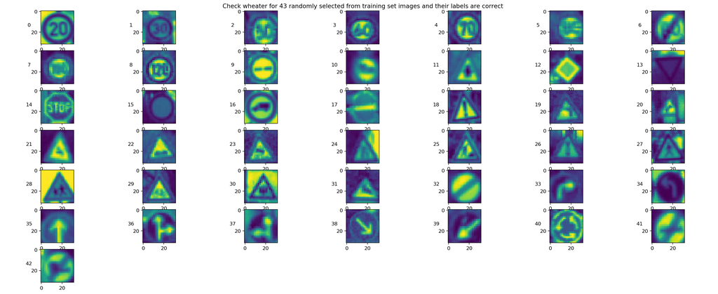

```python
#show trimmed images
fig = plt.figure(figsize=(25, 10), dpi=160)
ax = fig.add_subplot(111)    # The big subplot
ax.set_title('Check wheater for 43 randomly selected from training set images and their labels are correct')
ax.axis('off')

k = 1 #class/graph number
for image in images_crop_resize:
    ax = fig.add_subplot(n_row,n_col,k)
    ax.set_ylabel(k-1, rotation=0)
    plt.imshow(image)
    k+=1
```

```python
#this code preprocesses images from the train set (grayscale+trimmed+scaled versions)
X_train_crop = []
i=0

for k in range(X_train.shape[0]):
    image = grayscale(X_train[k])
    x_orig,y_orig = s_train[k]
    x_sel1, y_sel1, x_sel2, y_sel2 = c_train[k]
    n_x = image_shape[1]/x_orig
    n_y = image_shape[0]/y_orig
    x11 = int(x_sel1*n_x)
    y11 = int(y_sel1*n_y)
    x22 = int(x_sel2*n_x)
    y22 = int(y_sel2*n_y)
    image = image[x11:x22,y11:y22]#crop image outside secetion
    image = cv2.resize(image, (image_shape[1],image_shape[0]), interpolation = cv2.INTER_AREA)
    #image = normalize1(image)
    X_train_crop.append(image)
    i+=1


print('convertion into grayscale of the training set: finished')
X_train_crop = np.array(X_train_crop, dtype=object)
X_train_crop = X_train_crop[..., None]
print('new training set dimensions: ' + str(X_train_crop.shape))
```

```
convertion into grayscale of the training set: finished
new training set dimensions: (34799, 32, 32, 1)
```

```python
#this code preprocesses images from the valid set (grayscale+trimmed+scaled versions)
X_valid_crop = []
i=0

for k in range(X_valid.shape[0]):
    image = grayscale(X_valid[k])
    x_orig,y_orig = s_valid[k]
    x_sel1, y_sel1, x_sel2, y_sel2 = c_valid[k]
    n_x = image_shape[1]/x_orig
    n_y = image_shape[0]/y_orig
    x11 = int(x_sel1*n_x)
    y11 = int(y_sel1*n_y)
    x22 = int(x_sel2*n_x)
    y22 = int(y_sel2*n_y)
    image = image[x11:x22,y11:y22]#crop image outside secetion
    image = cv2.resize(image, (image_shape[1],image_shape[0]), interpolation = cv2.INTER_AREA)
    #image = normalize1(image)
    X_valid_crop.append(image)
    i+=1

print('validation set dimensions before convertion to grayscale: ' + str(X_valid.shape))
print('convertion into grayscale: finished')
X_valid_crop = np.array(X_valid_crop, dtype=object)
X_valid_crop = X_valid_crop[..., None]
print('new training set dimensions: ' + str(X_valid_crop.shape))
```

```
validation set dimensions before convertion to grayscale: (4410, 32, 32, 3)
convertion into grayscale: finished
new training set dimensions: (4410, 32, 32, 1)
```

### Model Architecture

```python
###neural network architecture

from sklearn.utils import shuffle
import tensorflow as tf

X_train_color = X_train
#shuffle the training data
X_train, y_train = shuffle(X_train_crop, y_train)

EPOCHS = 50
BATCH_SIZE = 128

from tensorflow.contrib.layers import flatten

def LeNet(x):
    # Arguments used for tf.truncated_normal, randomly defines variables for the weights and biases for each layer
    mu = 0
    sigma = 0.1

    # SOLUTION: Layer 1: Convolutional. Input = 32x32x1. Output = 28x28x6.
    conv1_W = tf.Variable(tf.truncated_normal(shape=(5, 5, 1, 6), mean = mu, stddev = sigma), name='conv1_W')
    conv1_b = tf.Variable(tf.zeros(6))
    conv1   = tf.nn.conv2d(x, conv1_W, strides=[1, 1, 1, 1], padding='VALID', name='conv_1') + conv1_b


    # SOLUTION: Activation.
    conv1 = tf.nn.relu(conv1)

    # SOLUTION: Pooling. Input = 28x28x6. Output = 14x14x6.
    conv1 = tf.nn.max_pool(conv1, ksize=[1, 2, 2, 1], strides=[1, 2, 2, 1], padding='VALID')

    # SOLUTION: Layer 2: Convolutional. Output = 10x10x16.
    conv2_W = tf.Variable(tf.truncated_normal(shape=(5, 5, 6, 16), mean = mu, stddev = sigma),name='conv2_W')
    conv2_b = tf.Variable(tf.zeros(16))
    conv2   = tf.nn.conv2d(conv1, conv2_W, strides=[1, 1, 1, 1], padding='VALID', name='conv_2') + conv2_b

    # SOLUTION: Activation.
    conv2 = tf.nn.relu(conv2)

    # SOLUTION: Pooling. Input = 10x10x16. Output = 5x5x16.
    conv2 = tf.nn.max_pool(conv2, ksize=[1, 2, 2, 1], strides=[1, 2, 2, 1], padding='VALID')

    # SOLUTION: Flatten. Input = 5x5x16. Output = 400.
    fc0   = flatten(conv2)

    # SOLUTION: Layer 3: Fully Connected. Input = 400. Output = 120.
    fc1_W = tf.Variable(tf.truncated_normal(shape=(400, 120), mean = mu, stddev = sigma))
    fc1_b = tf.Variable(tf.zeros(120))
    fc1   = tf.matmul(fc0, fc1_W) + fc1_b

    # SOLUTION: Activation.
    fc1    = tf.nn.relu(fc1)

    # SOLUTION: Layer 4: Fully Connected. Input = 120. Output = 84.
    fc2_W  = tf.Variable(tf.truncated_normal(shape=(120, 84), mean = mu, stddev = sigma))
    fc2_b  = tf.Variable(tf.zeros(84))
    fc2    = tf.matmul(fc1, fc2_W) + fc2_b

    # SOLUTION: Activation.
    fc2    = tf.nn.relu(fc2)

    # SOLUTION: Layer 5: Fully Connected. Input = 84. Output = 43.
    fc3_W  = tf.Variable(tf.truncated_normal(shape=(84, n_classes), mean = mu, stddev = sigma))
    fc3_b  = tf.Variable(tf.zeros(n_classes))
    logits = tf.matmul(fc2, fc3_W) + fc3_b

    return logits
```

```python
x = tf.placeholder(tf.float32, (None, 32, 32, 1))
y = tf.placeholder(tf.int32, (None))
one_hot_y = tf.one_hot(y, n_classes)
```

### Train, Validate and Test the Model

A validation set can be used to assess how well the model is performing. A low accuracy on the training and validation sets imply underfitting. A high accuracy on the training set but low accuracy on the validation set implies overfitting.

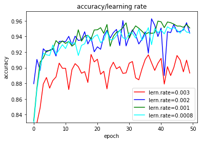

```python
#I trained the model with different learning rates (0.005,0.004,0.003,0.002,0.001,0.0008)
#following code plots the results

rates = [0.003,0.002,0.001,0.0008]

learning = {}
for rate in rates:
    file = open("learning_rates/" + str(rate) + '.csv', 'r')
    rate_tmp = []
    for line in file:
        rate_tmp.append(line[:-1])
    file.close()
    learning[rate]=rate_tmp

color = ['r','b','g','cyan','black','y']

plot,ax = plt.subplots()
ax.set_title('accuracy/learning rate')
ax.set_ylim(0.83, 0.972)
ax.set_xlabel('epoch')
ax.set_ylabel('accuracy')

i=0
for key in learning.keys():
    y1 = learning[key]
    x1 = range(len(y1))
    ax.plot(x1,y1,color[i],label='lern.rate='+str(key)) # plots accuracy for different learning rates and epochs
    ax.legend(loc='lower right')
    i+=1
plt.show()
```

```python
### the model is trained here.

import csv
import os #command to restart the kernel of jupyter
import time

rates = [0.005,0.004,0.003,0.002,0.001,0.0008]
#next row was commented, it used only for preliminary estimation of number of epochs for different learning rates
#files_num = len([name for name in os.listdir('learning_rates/') if os.path.isfile('learning_rates/' + name)])

rate = rates[4]

#next row was commented, it used only for preliminary estimation of number of epochs for different learning rates
#file = open("learning_rates/" + str(rate) + '.csv', 'w')

logits = LeNet(x)
cross_entropy = tf.nn.softmax_cross_entropy_with_logits(labels=one_hot_y, logits=logits)
loss_operation = tf.reduce_mean(cross_entropy)
optimizer = tf.train.AdamOptimizer(learning_rate = rate)
training_operation = optimizer.minimize(loss_operation)

correct_prediction = tf.equal(tf.argmax(logits, 1), tf.argmax(one_hot_y, 1))
accuracy_operation = tf.reduce_mean(tf.cast(correct_prediction, tf.float32))
saver = tf.train.Saver()

def evaluate(X_data, y_data):
    num_examples = len(X_data)
    total_accuracy = 0
    sess = tf.get_default_session()
    for offset in range(0, num_examples, BATCH_SIZE):
        batch_x, batch_y = X_data[offset:offset+BATCH_SIZE], y_data[offset:offset+BATCH_SIZE]
        accuracy = sess.run(accuracy_operation, feed_dict={x: batch_x, y: batch_y})
        total_accuracy += (accuracy * len(batch_x))
    return total_accuracy / num_examples


with tf.Session() as sess:
    sess.run(tf.global_variables_initializer())
    num_examples = len(X_train)

    print("Training...")
    print()
    for i in range(EPOCHS):
        X_train, y_train = shuffle(X_train, y_train)
        for offset in range(0, num_examples, BATCH_SIZE):
            end = offset + BATCH_SIZE
            batch_x, batch_y = X_train[offset:end], y_train[offset:end]
            sess.run(training_operation, feed_dict={x: batch_x, y: batch_y})

        validation_accuracy = evaluate(X_valid_crop, y_valid)
        print("EPOCH {} ...".format(i+1))
        print("Validation Accuracy = {:.3f}".format(validation_accuracy))
        print()

        #next row was commented, it used only for preliminary estimation of number of epochs for different learning rates
        #file.write(str(validation_accuracy)+'\n')

    saver.save(sess, './lenet')
    print("Model saved")
    #next row was commented, it used only for preliminary estimation of number of epochs for different learning rates
    #file.close()

#next row was commented, it used only for preliminary estimation of number of epochs for different learning rates
#if len(rates)==files_num+1:
#    pass
#else:
#    time.sleep(10)
#    os._exit(00)
```

```
Training...

EPOCH 1 ...
Validation Accuracy = 0.836

EPOCH 2 ...
Validation Accuracy = 0.877

EPOCH 3 ...
Validation Accuracy = 0.878

EPOCH 4 ...
Validation Accuracy = 0.908

EPOCH 5 ...
Validation Accuracy = 0.922

EPOCH 6 ...
Validation Accuracy = 0.928

EPOCH 7 ...
Validation Accuracy = 0.927

EPOCH 8 ...
Validation Accuracy = 0.942

EPOCH 9 ...
Validation Accuracy = 0.918

EPOCH 10 ...
Validation Accuracy = 0.938

EPOCH 11 ...
Validation Accuracy = 0.929

EPOCH 12 ...
Validation Accuracy = 0.927

EPOCH 13 ...
Validation Accuracy = 0.934
```

[output cut: 98 more lines]

```
Validation Accuracy = 0.949

EPOCH 47 ...
Validation Accuracy = 0.951

EPOCH 48 ...
Validation Accuracy = 0.947

EPOCH 49 ...
Validation Accuracy = 0.899

EPOCH 50 ...
Validation Accuracy = 0.938

Model saved
```

```python
X_test_crop = []
i=0

for k in range(X_test.shape[0]):
    image = grayscale(X_test[k])
    x_orig,y_orig = s_test[k]
    x_sel1, y_sel1, x_sel2, y_sel2 = c_test[k]
    n_x = image_shape[1]/x_orig
    n_y = image_shape[0]/y_orig
    x11 = int(x_sel1*n_x)
    y11 = int(y_sel1*n_y)
    x22 = int(x_sel2*n_x)
    y22 = int(y_sel2*n_y)
    if 0<x11<x22<=image.shape[1] and 0<y11<y22<=image.shape[0]:
        image = image[x11:x22,y11:y22]#crop image outside secetion
        image = cv2.resize(image, (image_shape[1],image_shape[0]), interpolation = cv2.INTER_AREA)
        #image = normalize(image) #this row was commented out, because normalization worsens model accuracy
                                  #according to my preliminary experiments with the model
        X_test_crop.append(image)
    else:
        X_test_crop.append(image)
    i+=1


print('dimensions of the test set before convertion to grayscale: ' + str(X_test.shape))
print('convertion into grayscale: finished')
X_test_crop = np.array(X_test_crop, dtype=object)
X_test_crop = X_test_crop[..., None]
print('new dimensions of the test set: ' + str(X_test_crop.shape))

with tf.Session() as sess:
    saver.restore(sess, tf.train.latest_checkpoint('.'))

    test_accuracy = evaluate(X_test_crop, y_test)
    print("Test Accuracy = {:.3f}".format(test_accuracy))
```

```
dimensions of the test set before convertion to grayscale: (12630, 32, 32, 3)
convertion into grayscale: finished
new dimensions of the test set: (12630, 32, 32, 1)
INFO:tensorflow:Restoring parameters from .\lenet
Test Accuracy = 0.925
```

## Step 3: Test a Model on New Images

I downloaded ten pictures of German traffic signs from the web and used my model to predict the traffic sign type.

### Load and Output the Images

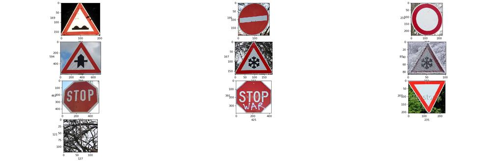

```python
### Load the images from "5-test-signs" folder and plot them here.

import os
import matplotlib.image as mpimg


pic_num = len(os.listdir("5-test-signs/"))

#find number of number of rows/cols and maximum size of pyplot.subplot()
if (int(math.sqrt(pic_num)))**2 == pic_num:
    n_col = n_row = math.sqrt(pic_num)
else:
    n_col = pic_num // int(math.sqrt(pic_num))
    n_row = pic_num // n_col + pic_num % n_col

cur_plot = 0

fig = plt.figure(figsize=(32, 10), dpi=80)
ax = fig.add_subplot(111)    # main subplot
ax.axis('off')

#itirates over the folder with images and shows them
for pic in os.listdir("5-test-signs/"):
    image = mpimg.imread("5-test-signs/" + pic)
    cur_plot+=1
    ax = fig.add_subplot(n_row,n_col,cur_plot)
    ax.set_xlabel(image.shape[1])
    ax.set_ylabel(image.shape[0], rotation=0)
    plt.imshow(image)
```

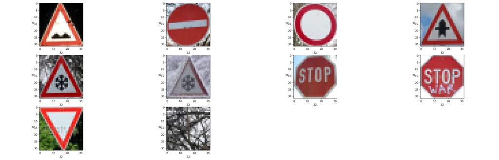

```python
#following code scales the images from the web to 32x32x1
cur_plot = 0

fig = plt.figure(figsize=(32, 10), dpi=80)
ax = fig.add_subplot(111)    # The big subplot
ax.axis('off')

test_images = []
test_images_color = []

#itirates over the folder with images and shows them
for pic in os.listdir("5-test-signs/"):
    image = mpimg.imread("5-test-signs/" + pic)
    image = cv2.resize(image, (image_shape[1],image_shape[0]), interpolation = cv2.INTER_AREA)
    test_images_color.append(image)
    cur_plot+=1
    ax = fig.add_subplot(n_row,n_col,cur_plot)
    ax.set_xlabel(image.shape[1])
    ax.set_ylabel(image.shape[0], rotation=0)
    plt.imshow(image)# Display the image
    image = grayscale(image)
    test_images.append(image)

test_images1 = np.array(test_images, dtype=object)
test_images1 = test_images1[..., None]

test_labels = [22,17,15,11,30,30,14,14,13,0]
```

### Prediction of the Sign Type for Each Image

```python
### Predictions are being calculated for each image here.
### Pre-process of the images with the same pre-processing pipeline used earlier.

rate = 0.001

with tf.Session() as sess:
    saver.restore(sess, tf.train.latest_checkpoint('.'))

    #result = sess.run(logits, feed_dict={x: test_images})
    result = sess.run(logits, feed_dict={x: test_images1})
#print("nn result: %s , expected: %s", result, test_labels)
results = [np.argmax(i) for i in result]
print('neural network sign predictions, zero means incorrect prediction')
print([i if i == j else 0 for i, j in zip(results, test_labels) ])
```

```
INFO:tensorflow:Restoring parameters from .\lenet
neural network sign predictions, zero means incorrect prediction
[22, 17, 15, 11, 30, 30, 14, 14, 13, 0]
```

### Analyze Performance

```python
### Accuracy calculated for 10 new images.

with tf.Session() as sess:
    saver.restore(sess, tf.train.latest_checkpoint('.'))

    test_accuracy = evaluate(test_images1, test_labels)
    print("Test Accuracy = {:.3f}".format(test_accuracy))
```

```
INFO:tensorflow:Restoring parameters from .\lenet
Test Accuracy = 0.900
```

### Top 3 Softmax Probabilities For Each Image Found on the Web

```python
### Follwing code prints top three softmax probabilities for the predictions on the German traffic sign images found on the web.

output = []
with tf.Session() as sess:
    y = sess.run(tf.nn.softmax(result))
    for i in range(len(result)):
        output.append(sess.run(tf.nn.top_k(tf.constant(y[i]), k=3)))
        print("picture number " + str(i+1) + ":  ", end = '')
        print(output[i])
```

```
picture number 1:  TopKV2(values=array([  1.00000000e+00,   3.39671054e-14,   1.61444785e-14], dtype=float32), indices=array([22,  0, 25]))
picture number 2:  TopKV2(values=array([  1.00000000e+00,   3.36704928e-19,   6.52081102e-25], dtype=float32), indices=array([17, 14, 20]))
picture number 3:  TopKV2(values=array([  1.00000000e+00,   2.93292358e-16,   7.95178158e-20], dtype=float32), indices=array([15,  2, 40]))
picture number 4:  TopKV2(values=array([  1.00000000e+00,   5.63426699e-14,   1.10788529e-34], dtype=float32), indices=array([11, 27, 30]))
picture number 5:  TopKV2(values=array([  1.00000000e+00,   2.15859703e-08,   5.24542517e-15], dtype=float32), indices=array([30, 28, 11]))
picture number 6:  TopKV2(values=array([  5.85210800e-01,   4.14788246e-01,   4.44743534e-07], dtype=float32), indices=array([30, 11, 29]))
picture number 7:  TopKV2(values=array([  1.00000000e+00,   4.99432495e-09,   3.64846278e-11], dtype=float32), indices=array([14, 39, 13]))
picture number 8:  TopKV2(values=array([  1.00000000e+00,   1.52759819e-11,   2.22230071e-13], dtype=float32), indices=array([14,  1, 25]))
picture number 9:  TopKV2(values=array([  1.00000000e+00,   4.38013394e-34,   4.22565083e-38], dtype=float32), indices=array([13, 39,  5]))
picture number 10:  TopKV2(values=array([  6.40612960e-01,   3.59386951e-01,   1.13161919e-11], dtype=float32), indices=array([ 6, 36,  5]))
```

### Plot of the corresponding images for top 3 probabilities

[figure not shown]

```python
fig = plt.figure(figsize=(25, 10), dpi=160)
ax = fig.add_subplot(111)    # The big subplot
ax.set_title('First column: images from internet. Column 1-3: top 3 predictions from the NN (from left to right)')
ax.axis('off')

n_row = 10
n_col = 4

k = 0 #class/graph number
for sign in output:
    ax = fig.add_subplot(n_row,n_col,4*k+1)
    ax.set_ylabel(test_labels[k], rotation=0)
    image = test_images_color[k]
    plt.imshow(test_images_color[k])
    for i in range(len(sign[1])):
        ax = fig.add_subplot(n_row,n_col,4*k+1+i+1)
        ax.set_ylabel(sign[1][i], rotation=0)
        image = X_train_color[images[sign[1][i]][1]]
        plt.imshow(image)
    k+=1
```

## Step 4: Visualization the Neural Network's State with Test Images

In this section after successfully training the neural network I can see what it's feature maps look like by plotting the output of the network's weight layers in response to a test stimuli image. From these plotted feature maps, it's possible to see what characteristics of an image the network finds interesting. For a sign, maybe the inner network feature maps react with high activation to the sign's boundary outline or to the contrast in the sign's painted symbol.

```
INFO:tensorflow:Restoring parameters from .\lenet
```

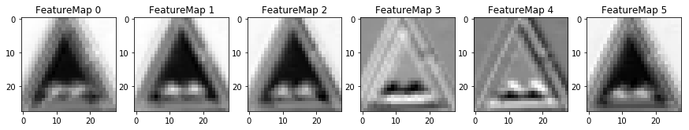

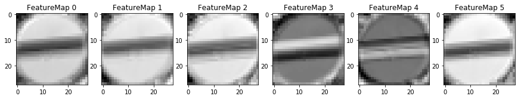

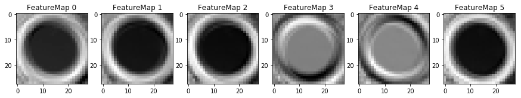

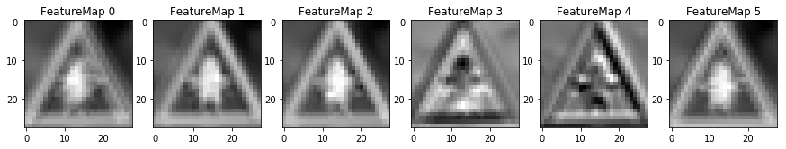

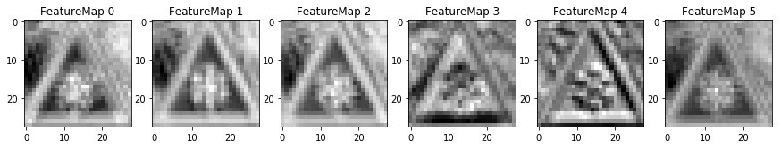

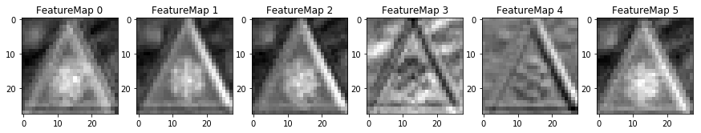

[figure not shown]

[figure not shown]

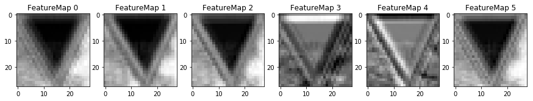

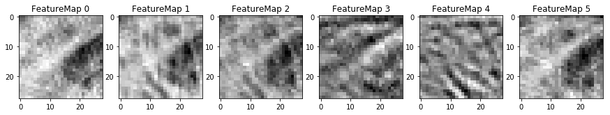

```python
### Visualize your network's feature maps here.

# image_input: the test image being fed into the network to produce the feature maps
# tf_activation: should be a tf variable name used during your training procedure that represents the calculated state of a specific weight layer
# activation_min/max: can be used to view the activation contrast in more detail, by default matplot sets min and max to the actual min and max values of the output
# plt_num: used to plot out multiple different weight feature map sets on the same block, just extend the plt number for each new feature map entry

def outputFeatureMap(image_input, tf_activation, activation_min=-1, activation_max=-1 ,plt_num=1):
    # image_input will be preproccessed in a way your network expects
    # with size, normalization, etc if needed
    activation = tf_activation.eval(session=sess,feed_dict={x : image_input})
    featuremaps = activation.shape[3]
    plt.figure(plt_num, figsize=(15,15))
    for featuremap in range(featuremaps):
        plt.subplot(4,6, featuremap+1) # sets the number of feature maps to show on each row and column
        plt.title('FeatureMap ' + str(featuremap)) # displays the feature map number
        if activation_min != -1 & activation_max != -1:
            plt.imshow(activation[0,:,:, featuremap], interpolation="nearest", vmin =activation_min, vmax=activation_max, cmap="gray")
        elif activation_max != -1:
            plt.imshow(activation[0,:,:, featuremap], interpolation="nearest", vmax=activation_max, cmap="gray")
        elif activation_min !=-1:
            plt.imshow(activation[0,:,:, featuremap], interpolation="nearest", vmin=activation_min, cmap="gray")
        else:
            plt.imshow(activation[0,:,:, featuremap], interpolation="nearest", cmap="gray")

pltnum = 0
with tf.Session() as sess:
    new_saver = tf.train.import_meta_graph('lenet.meta')
    new_saver.restore(sess, tf.train.latest_checkpoint('.'))

    for img in test_images1:
        pltnum+=1
        img = np.expand_dims(img, axis=0)
        conv_1W = tf.get_default_graph().get_tensor_by_name("conv1_W:0")
        conv_2W = tf.get_default_graph().get_tensor_by_name("conv2_W:0")
        conv11 = tf.get_default_graph().get_tensor_by_name("conv_1:0")
        conv22 = tf.get_default_graph().get_tensor_by_name("conv_2:0")

        explore = conv11
        outputFeatureMap(img, explore, plt_num=pltnum)
```